# STA 138 FQ 2020 Discussion 1

Yidong Zhou

09/30/2020

## Discussion Sessions and Office Hours

TA: Yidong Zhou (ydzhou@ucdavis.edu)

We will use Piazza (access code “overdispersion” without the quotes) for this course to answer questions and facilitate discussion. Ask routine questions about course material and policies there; direct any sensitive or specifically personal matters to me or the instructor by email (**email please, not Canvas message**). In any emails, please include the text “**[STA138-FALL2020]**” (without the quotes) in the subject line.

Discussion sessions:

- Thursdays 09:00-09:50 am PT: https://ucdstats.zoom.us/j/98190589653?pwd=K1lVTElLL1V0VVBNemd3RklxV1dXZz09
- Thursdays 10:00-10:50 am PT: https://ucdstats.zoom.us/j/99471664794?pwd=eCtzRWtVeEFhQmlSd3hyL1B6b2w2Zz09

Office hours:

- Tuesdays 09:00-11:00 am PT: https://ucdstats.zoom.us/j/99625197827?pwd=OTFJY2FSZmozWVppMm1CSm82cVhTUT09

*All the above zoom links can be found in Canvas –> Syllabus.*

## Review

- Installation of R and RStudio: https://www.datacamp.com/community/tutorials/installing-R-windows-mac-ubuntu
- Introduction to RStudio, including file creation, panel structure.
- R basics, including variable creation, arithmetic calculation, vectors, and some basic functions: `help()`, `?`, `rep`, `seq`.

## Data Manipulation

We will learn how to perform data manipulation in R programming language along with data processing. We will also overview the three operators such as subsetting, manipulation as well as sorting in R. Also, we will learn about data structures in R, how to create subsets in R and usage of R `sample()` command, ways to visualize data in R.

With the help of data structures, we can represent data in the form of data analytics. Data Manipulation in R can be carried out for further analysis and visualization. The first step is to figure out how to import data in R.

`Environment` panel –> `Import Dataset` –> `From Text(readr)...` –> `browse` –> `Import`

Secondly, you need to be familiar with basic **data structures** in R (`class` function):

- `Vectors`: ordered containers of primitive elements and are used for 1-dimensional data.
- `Matrices`: rectangular collections of elements and are useful when all data is of a single class that is numeric or characters.
- `Lists`: ordered containers for arbitrary elements and are used for higher dimension data, like customer data information of an organization. When data cannot be represented as an array or a data frame, the list is the best choice. This is because lists can contain all kinds of other objects, including other lists or data frames, and in that sense, they are very flexible.
- `Data Frames`: two-dimensional containers for records and variables and are used for representing data from spreadsheets etc. It is similar to a single table in the database.

(**data types**: integer, numeric, logical, character, complex.)

### subset data

The process of creating samples is called subsetting. Different methods of subsetting in R are:

- `$`: The dollar sign operator selects a single element of data. The result of this operator is always a vector when we use it with a `data frame`.
- `[[`: Similar to `$` in R, the double square brackets operator in R also returns a single element, but it offers the flexibility of referring to the elements by position rather than by name. It can be used for data frames and lists.
- `[`: The single square bracket operator in R returns multiple elements of data. The index within the square brackets can be a numeric vector, a logical vector, or a character vector.

For example: To retrieve 5 rows and all columns of already built-in dataset `mtcars`, the below command, is used:

```r
data(mtcars)
mtcars$mpg# column called mpg
```

```
##  [1] 21.0 21.0 22.8 21.4 18.7 18.1 14.3 24.4 22.8 19.2 17.8 16.4 17.3 15.2 10.4
## [16] 10.4 14.7 32.4 30.4 33.9 21.5 15.5 15.2 13.3 19.2 27.3 26.0 30.4 15.8 19.7
## [31] 15.0 21.4
```

```r
mtcars[[1]]# first column
```

```
##  [1] 21.0 21.0 22.8 21.4 18.7 18.1 14.3 24.4 22.8 19.2 17.8 16.4 17.3 15.2 10.4
## [16] 10.4 14.7 32.4 30.4 33.9 21.5 15.5 15.2 13.3 19.2 27.3 26.0 30.4 15.8 19.7
## [31] 15.0 21.4
```

```r
mtcars[1:5, ]# first five rows
```

```
##                    mpg cyl disp  hp drat    wt  qsec vs am gear carb
## Mazda RX4         21.0   6  160 110 3.90 2.620 16.46  0  1    4    4
## Mazda RX4 Wag     21.0   6  160 110 3.90 2.875 17.02  0  1    4    4
## Datsun 710        22.8   4  108  93 3.85 2.320 18.61  1  1    4    1
## Hornet 4 Drive    21.4   6  258 110 3.08 3.215 19.44  1  0    3    1
## Hornet Sportabout 18.7   8  360 175 3.15 3.440 17.02  0  0    3    2
```

```r
mtcars[mtcars$cyl==8, ]# rows with 8 cylinders
```

```
##                      mpg cyl  disp  hp drat    wt  qsec vs am gear carb
## Hornet Sportabout   18.7   8 360.0 175 3.15 3.440 17.02  0  0    3    2
## Duster 360          14.3   8 360.0 245 3.21 3.570 15.84  0  0    3    4
## Merc 450SE          16.4   8 275.8 180 3.07 4.070 17.40  0  0    3    3
## Merc 450SL          17.3   8 275.8 180 3.07 3.730 17.60  0  0    3    3
## Merc 450SLC         15.2   8 275.8 180 3.07 3.780 18.00  0  0    3    3
## Cadillac Fleetwood  10.4   8 472.0 205 2.93 5.250 17.98  0  0    3    4
## Lincoln Continental 10.4   8 460.0 215 3.00 5.424 17.82  0  0    3    4
## Chrysler Imperial   14.7   8 440.0 230 3.23 5.345 17.42  0  0    3    4
## Dodge Challenger    15.5   8 318.0 150 2.76 3.520 16.87  0  0    3    2
## AMC Javelin         15.2   8 304.0 150 3.15 3.435 17.30  0  0    3    2
## Camaro Z28          13.3   8 350.0 245 3.73 3.840 15.41  0  0    3    4
## Pontiac Firebird    19.2   8 400.0 175 3.08 3.845 17.05  0  0    3    2
## Ford Pantera L      15.8   8 351.0 264 4.22 3.170 14.50  0  1    5    4
## Maserati Bora       15.0   8 301.0 335 3.54 3.570 14.60  0  1    5    8
```

#### `sample()` command in R

For example, to create a sample of 10 simulations of a die, below command is used:

```r
sample(1:6, 10, replace=TRUE)
```

```
##  [1] 2 3 6 6 4 4 6 5 1 3
```

### draw histograms

Histogram can be created using the `hist()` function in R programming language. This function takes in a vector of values for which the histogram is plotted.

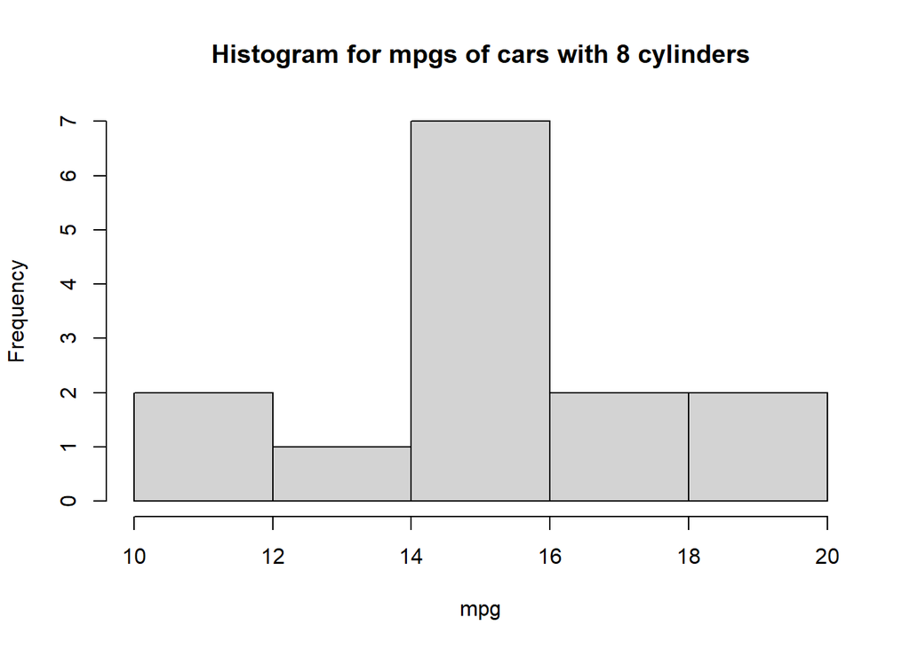

```r
hist(mtcars[mtcars$cyl==8, ]$mpg, main='Histogram for mpgs of cars with 8 cylinders', xlab='mpg')
```

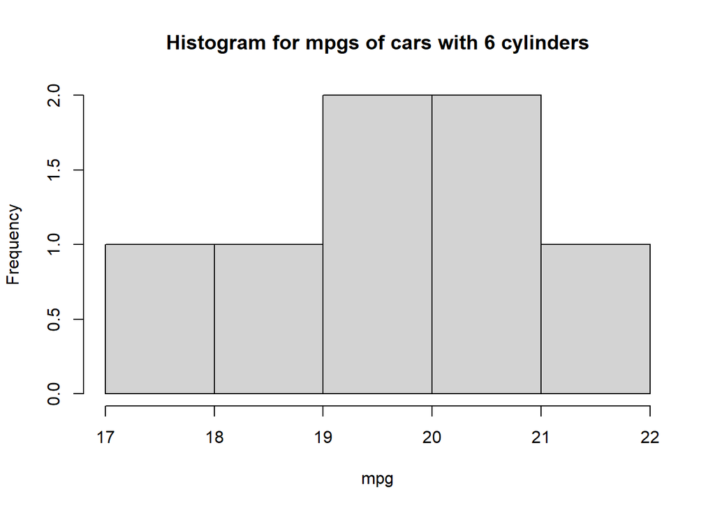

```r
hist(mtcars[mtcars$cyl==6, ]$mpg, main='Histogram for mpgs of cars with 6 cylinders', xlab='mpg')
```

### compute means and medians

```r
mean(mtcars[mtcars$cyl==8, ]$mpg)
```

```
## [1] 15.1
```

```r
mean(mtcars[mtcars$cyl==6, ]$mpg)
```

```
## [1] 19.74286
```

```r
median(mtcars[mtcars$cyl==8, ]$mpg)
```

```
## [1] 15.2
```

```r
median(mtcars[mtcars$cyl==6, ]$mpg)
```

```
## [1] 19.7
```

```r
var(mtcars[mtcars$cyl==8, ]$mpg)
```

```
## [1] 6.553846
```

```r
sd(mtcars[mtcars$cyl==8, ]$mpg)
```

```
## [1] 2.560048
```

```r
summary(mtcars)
```

```
##       mpg             cyl             disp             hp
##  Min.   :10.40   Min.   :4.000   Min.   : 71.1   Min.   : 52.0
##  1st Qu.:15.43   1st Qu.:4.000   1st Qu.:120.8   1st Qu.: 96.5
##  Median :19.20   Median :6.000   Median :196.3   Median :123.0
##  Mean   :20.09   Mean   :6.188   Mean   :230.7   Mean   :146.7
##  3rd Qu.:22.80   3rd Qu.:8.000   3rd Qu.:326.0   3rd Qu.:180.0
##  Max.   :33.90   Max.   :8.000   Max.   :472.0   Max.   :335.0
##       drat             wt             qsec             vs
##  Min.   :2.760   Min.   :1.513   Min.   :14.50   Min.   :0.0000
##  1st Qu.:3.080   1st Qu.:2.581   1st Qu.:16.89   1st Qu.:0.0000
##  Median :3.695   Median :3.325   Median :17.71   Median :0.0000
##  Mean   :3.597   Mean   :3.217   Mean   :17.85   Mean   :0.4375
##  3rd Qu.:3.920   3rd Qu.:3.610   3rd Qu.:18.90   3rd Qu.:1.0000
##  Max.   :4.930   Max.   :5.424   Max.   :22.90   Max.   :1.0000
##        am              gear            carb
##  Min.   :0.0000   Min.   :3.000   Min.   :1.000
##  1st Qu.:0.0000   1st Qu.:3.000   1st Qu.:2.000
##  Median :0.0000   Median :4.000   Median :2.000
##  Mean   :0.4062   Mean   :3.688   Mean   :2.812
##  3rd Qu.:1.0000   3rd Qu.:4.000   3rd Qu.:4.000
##  Max.   :1.0000   Max.   :5.000   Max.   :8.000
```

### draw mosaic plots

The Mosaic Plot in R Programming is very useful to visualize the data from the contingency table or two-way frequency table. The R Mosaic Plot draws a rectangle, and its height represents the proportional value.

```r
table(mtcars$am, mtcars$cyl)# contingency table or two-way frequency table
```

```
##
##      4  6  8
##   0  3  4 12
##   1  8  3  2
```

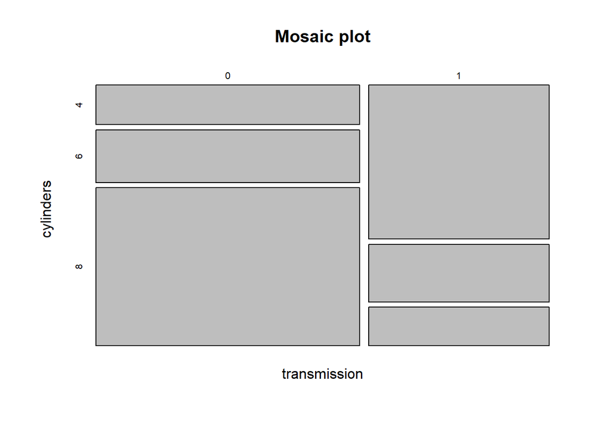

```r
mosaicplot(mtcars$am~mtcars$cyl, main='Mosaic plot', xlab='transmission', ylab='cylinders')
```

## Code Appendix

```r
data(mtcars)
mtcars$mpg# column called mpg
mtcars[[1]]# first column
mtcars[1:5, ]# first five rows
mtcars[mtcars$cyl==8, ]# rows with 8 cylinders
sample(1:6, 10, replace=TRUE)
hist(mtcars[mtcars$cyl==8, ]$mpg, main='Histogram for mpgs of cars with 8 cylinders', xlab='mpg')
hist(mtcars[mtcars$cyl==6, ]$mpg, main='Histogram for mpgs of cars with 6 cylinders', xlab='mpg')
mean(mtcars[mtcars$cyl==8, ]$mpg)
mean(mtcars[mtcars$cyl==6, ]$mpg)
median(mtcars[mtcars$cyl==8, ]$mpg)
median(mtcars[mtcars$cyl==6, ]$mpg)
var(mtcars[mtcars$cyl==8, ]$mpg)
sd(mtcars[mtcars$cyl==8, ]$mpg)
summary(mtcars)
table(mtcars$am, mtcars$cyl)# contingency table or two-way frequency table
mosaicplot(mtcars$am~mtcars$cyl, main='Mosaic plot', xlab='transmission', ylab='cylinders')
```